# Outcomes from a pilot dose comparison study of naming therapy in aphasia - Analysis workflow

Sam Harvey, Marcella Carragher, Michael Walsh Dickey, Miranda Rose

2022

This document provides a summary of data processing and analyses for a pilot study which evaluated the effect of personalising treatment dose of a lexical retrieval treatment in four people with chronic post-stroke aphasia.

## Data processing, visualisation, and analyses

#### Load packages

```r
# load packages

library(knitr)
library(here)
library(tidyverse)
library(lme4) # used to run GLMMs
library(readxl) # used to import xlsx spreadsheets
library(broom.mixed) # used tidy() to exponentiate GLM model outputs into ORs with CIs
library(sjPlot) # used to tabulate model outputs
library(ggeffects) # used to plot charts
library(gridExtra) # used to arrange plots
library(kableExtra) # used to tabulate data
```

#### Import, organise, and preview data

```r
#--- Import probe data ---#
probeData <- read_excel(here("data", "p3-6.probeData.xlsx")) %>%
  mutate(dose_code1 = as.factor(dose_code1), # these columns were numbers (not strings), convert manually
         dose_code2 = as.factor(dose_code2),
         phase = as.factor(phase),
         times_treatedV2 = as.factor(times_treatedV2),
         participant = as.factor(participant),
         set = as.factor(set))

#--- Import naming test data ---#
namingTestData <- read_excel(here("data", "p3-6.namingTestData.xlsx")) %>%
  pivot_longer(cols = time_1_a:time_4, names_to = "time", values_to = "response") %>%
  separate("time", into = c("drop", "time", "baseline_session"), sep = "_") %>%
  mutate_if(is.character, as.factor) %>% # any columns that are strings, make factors
  mutate(doseCode = as.factor(doseCode), # these columns were numbers (not strings), do it manually
    item_num = as.factor(item_num),
    participant = as.factor(participant))
```

Example of the hierarchically structured naming probe data. Naming probe data was collected over 21 probe sessions.

| seq_no | participant | age | tpo | wab | corsi | tea_ve_raw | tea_ve_time | tea_ec | pic_span_trials | pic_span_items | set_size | item | item_num | word_freq | phon_length | acc_cat | dose | dose_code1 | dose_code2 | doseSum | set | session | period | phase | phaseV2 | low_phase | mod_phase | high_phase | phase_label | … |
| --- | --- | --- | --- | --- | --- | --- | --- | --- | --- | --- | --- | --- | --- | --- | --- | --- | --- | --- | --- | --- | --- | --- | --- | --- | --- | --- | --- | --- | --- | --- |
| 1 | 3 | 54 | 119 | 66.8 | 3 | 0 | na | 3 | 2.5 | 32 | 15 | basketball | 16 | 2.6243 | 9 | 0 | moderate | C | 2 | 1 | 2 | 1 | 1 | 0 | 0 | na | 0 | na | baseline | … |
| 2 | 3 | 54 | 119 | 66.8 | 3 | 0 | na | 3 | 2.5 | 32 | 15 | basketball | 16 | 2.6243 | 9 | 0 | moderate | C | 2 | 1 | 2 | 2 | 1 | 0 | 0 | na | 0 | na | baseline | … |
| 3 | 3 | 54 | 119 | 66.8 | 3 | 0 | na | 3 | 2.5 | 32 | 15 | basketball | 16 | 2.6243 | 9 | 0 | moderate | C | 2 | 1 | 2 | 3 | 1 | 0 | 0 | na | 0 | na | baseline | … |
| 4 | 3 | 54 | 119 | 66.8 | 3 | 0 | na | 3 | 2.5 | 32 | 15 | basketball | 16 | 2.6243 | 9 | 0 | moderate | C | 2 | 1 | 2 | 4 | 1 | 0 | 0 | na | 0 | na | baseline | … |
| 5 | 3 | 54 | 119 | 66.8 | 3 | 0 | na | 3 | 2.5 | 32 | 15 | basketball | 16 | 2.6243 | 9 | 0 | moderate | C | 2 | 1 | 2 | 5 | 1 | 0 | 0 | na | 0 | na | baseline | … |
| 6 | 3 | 54 | 119 | 66.8 | 3 | 0 | na | 3 | 2.5 | 32 | 15 | basketball | 16 | 2.6243 | 9 | 0 | moderate | C | 2 | 1 | 2 | 6 | 1 | 0 | 0 | na | 0 | na | baseline | … |
| 7 | 3 | 54 | 119 | 66.8 | 3 | 0 | na | 3 | 2.5 | 32 | 15 | basketball | 16 | 2.6243 | 9 | 0 | moderate | C | 2 | 1 | 2 | 7 | 2 | 1 | 1 | na | 1 | na | treatment | … |
| 8 | 3 | 54 | 119 | 66.8 | 3 | 0 | na | 3 | 2.5 | 32 | 15 | basketball | 16 | 2.6243 | 9 | 0 | moderate | C | 2 | 1 | 2 | 8 | 2 | 1 | 1 | na | 1 | na | treatment | … |
| 9 | 3 | 54 | 119 | 66.8 | 3 | 0 | na | 3 | 2.5 | 32 | 15 | basketball | 16 | 2.6243 | 9 | 0 | moderate | C | 2 | 1 | 2 | 9 | 2 | 1 | 1 | na | 1 | na | treatment | … |
| 10 | 3 | 54 | 119 | 66.8 | 3 | 0 | na | 3 | 2.5 | 32 | 15 | basketball | 16 | 2.6243 | 9 | 0 | moderate | C | 2 | 1 | 2 | 10 | 2 | 1 | 1 | na | 1 | na | treatment | … |

Example of the hierarchically structured naming test data. Naming test data was collected pre-treatment, immediately post-treatment, 4-weeks post, and 12-weeks post. Picture items were named three times at the pre-treatment time point, and once at each other time point.

| participant | age | tpo | wab | corsi | tea_ve_raw | tea_ve_time | tea_ec | pic_span_trials | pic_span_items | set_size | item_num | item | inclusion | acc_cat | Freq | Phon_length | Set | dose | doseCode | drop | time | baseline_session | response |
| --- | --- | --- | --- | --- | --- | --- | --- | --- | --- | --- | --- | --- | --- | --- | --- | --- | --- | --- | --- | --- | --- | --- | --- |
| 3 | 54 | 119 | 66.8 | 3 | 0 | na | 3 | 2.5 | 32 | 11 | 1 | accordion | 0 | 0 | 1.6721 | 7 | NA | NA | 9 | time | 1 | a | 0 |
| 3 | 54 | 119 | 66.8 | 3 | 0 | na | 3 | 2.5 | 32 | 11 | 1 | accordion | 0 | 0 | 1.6721 | 7 | NA | NA | 9 | time | 1 | b | 0 |
| 3 | 54 | 119 | 66.8 | 3 | 0 | na | 3 | 2.5 | 32 | 11 | 1 | accordion | 0 | 0 | 1.6721 | 7 | NA | NA | 9 | time | 1 | c | 0 |
| 3 | 54 | 119 | 66.8 | 3 | 0 | na | 3 | 2.5 | 32 | 11 | 1 | accordion | 0 | 0 | 1.6721 | 7 | NA | NA | 9 | time | 2 | NA | 0 |
| 3 | 54 | 119 | 66.8 | 3 | 0 | na | 3 | 2.5 | 32 | 11 | 1 | accordion | 0 | 0 | 1.6721 | 7 | NA | NA | 9 | time | 3 | NA | 0 |
| 3 | 54 | 119 | 66.8 | 3 | 0 | na | 3 | 2.5 | 32 | 11 | 1 | accordion | 0 | 0 | 1.6721 | 7 | NA | NA | 9 | time | 4 | NA | 0 |
| 3 | 54 | 119 | 66.8 | 3 | 0 | na | 3 | 2.5 | 32 | 11 | 2 | anchor | 0 | 0 | 2.2765 | 4 | NA | NA | 9 | time | 1 | a | 0 |
| 3 | 54 | 119 | 66.8 | 3 | 0 | na | 3 | 2.5 | 32 | 11 | 2 | anchor | 0 | 0 | 2.2765 | 4 | NA | NA | 9 | time | 1 | b | 0 |
| 3 | 54 | 119 | 66.8 | 3 | 0 | na | 3 | 2.5 | 32 | 11 | 2 | anchor | 0 | 0 | 2.2765 | 4 | NA | NA | 9 | time | 1 | c | 0 |
| 3 | 54 | 119 | 66.8 | 3 | 0 | na | 3 | 2.5 | 32 | 11 | 2 | anchor | 0 | 0 | 2.2765 | 4 | NA | NA | 9 | time | 2 | NA | 0 |

##### Create data frames

```r
# Create probeData data frames for Analysis 1 - Learning effects

mr.probeData <- probeData %>% filter(participant == 3) # Include only participant 3's data (MR)
ip.probeData <- probeData %>% filter(participant == 4)
lr.probeData <- probeData %>% filter(participant == 5)
ts.probeData <- probeData %>% filter(participant == 6)

# Create namingTestData data frames for Analysis 2 - Maintenance effects
mr.namingTestData <- namingTestData %>% filter(participant == 3) # Include only participant 3's data (MR)
ip.namingTestData <- namingTestData %>% filter(participant == 4)
lr.namingTestData <- namingTestData %>% filter(participant == 5)
ts.namingTestData <- namingTestData %>% filter(participant == 6)
```

## Visualise data

#### Plot multiple-baselines charts

Example of code used to plot participant MR’s multiple-baselines chart

```r
# reorder set factor levels (untreated, low dose, moderate dose, high dose)
mr.probeData$set <- factor(mr.probeData$set, levels = c("1", "3", "2", "4"))

# create facet labels
mr.set_names <- c(`1` = "Untreated", `2` = "Moderate dose", `3` = "Low dose", `4` = "High dose")

mr.probePlot <- mr.probeData %>%
  group_by(set, session, phase) %>%
  summarize(macc = mean(response))  %>%
  ggplot(aes(y = macc, x = session, color = phase)) +
  facet_wrap(~ set, nrow=4, labeller = as_labeller(mr.set_names)) +
  labs(
    title = "MR",
    x = "Probe session",
    y = "Proportional accuracy") +
  scale_color_manual(
    values = c("#C00000", "#06A11C", "#ED7D31"),
    name = "Phase",
    labels = c("Baseline/Untreated", "Treatment", "Post-treatment")) +
  theme(
    text = element_text(size = 10, family = "serif"),
    plot.title = element_text(hjust = 0),
    legend.position = "NULL",
    panel.background = element_rect(fill = "white"),
    panel.grid.major.x = element_blank(),
    panel.grid.major.y = element_line(colour = "#CCCCCC"),
    strip.background = element_rect(fill = 'white'),
    axis.ticks = element_blank()) +
  geom_point(size = 2) +
  geom_line(size = .8) +
  scale_x_continuous(
    breaks = seq(1,21,1),
    limits = c(1,21)) +
  scale_y_continuous(
    breaks = seq(0,1,.2),
    limits = c(0,1))
```

#### Figure

Multiple-baselines case charts depicting proportional naming accuracy by probe session across the four dose conditions in the multiple-baselines design.

[figure not shown]

#### Plot pre/post/follow up charts

Example of code used to plot participant MR’s pre/post/follow up chart

```r
mr.barplot <- namingTestData %>%
  filter(participant == 3) %>%
  group_by(doseCode, time) %>%
  summarize(macc = mean(response)) %>%
  ggplot(aes(y = macc, x = time, color = doseCode)) +
  geom_col(aes(fill = doseCode), color = "black", width = .5, position = position_dodge(.65)) +
  labs(title = "MR", x = "", y = "Proportional accuracy") +
  scale_fill_manual(
    values = c("black", "#FAFAFA", "#E5E5E5", "#A3A3A3", "#525252"),
    name = NULL,
    labels = c("Unallocated", "Untreated", "Low dose", "Moderate dose", "High dose")) +
  theme(
    text = element_text(size = 10, family = "serif"),
    plot.title = element_text(size = 12, hjust = 0),
    legend.position = 'NULL',
    panel.background = element_blank(),
    panel.grid.major = element_blank(),
    panel.grid.minor = element_blank(),
    axis.line = element_line(colour = "black"),
    axis.title = element_text(size = 10, colour = "black", margin = margin(b = 10)),
    axis.title.y = element_text(margin = margin(r = 10)),
    axis.text = element_text(size = 10, colour = "black"),
    axis.text.x = element_text(margin = margin(t = 10)),
    axis.text.y = element_text(margin = margin(r = 10)),
    axis.ticks.y = element_line(colour = "black"),
    axis.ticks.x = element_blank()) +
  guides(
    fill = guide_legend(
      keywidth = 1.2, keyheight = 1.2, default.unit = "cm")) +
  scale_x_discrete(
    labels = c("Pre", "Post", "4w post", "12w post"),
    breaks = seq(1, 4, 1)) +
  scale_y_continuous(
    expand = expansion(0),
    breaks = seq(0,1,.2),
    limits = c(0,1))
```

#### Figure

Proportion of accurately named pictures on the naming test conducted at four time points, by dose condition.

[figure not shown]

## Analysis 1: Learning effects throughout treatment

Analysis 1 modelled day-by-day learning effects throughout treatment by estimating item-level naming accuracy after each subsequent treatment day relative to baseline across the three dose conditions and included comparisons with the untreated condition. This approach is analogous to analyses based on visual inspection such as Conservative Dual-Criterion analysis (Fisher et al., 2003) and non-parametric statistical approaches such as Tau-U or Non-Overlap of Pairs (Parker et al., 2011) that attempt to determine whether performance during the treatment phase significantly exceeds performance during the baseline phase.

We used generalised logistic mixed effects models including an ordinal times_treated variable (which increments with each treatment day). Using an ordinal variable avoids the assumption of linearity during treatment, allowing estimation of the difference in the likelihood of a correct response in a naming probe after each treatment day, compared to baseline. We included fixed-effects for item-level (word frequency, phoneme length) characteristics. The random-effects structure included random intercepts by-item. Models including random slopes for fixed effects and interaction terms failed to converge. Models of identical structure were fitted to each participant’s data separately allowing within-subject estimation of the effect of treatment versus no treatment for each dose condition and comparison of the effect of each dose condition.

Model specification: First, we constructed a model with maximal random effects structure (intercepts and slopes for all fixed effects and interactions). This model was overspecified (singular fit). We then followed the model simplification process described by Bates et al. (2015) until we arrived at a set of identical models that converged for all participant’s data, fitted separately. The iterative reduction of model complexity process described by Bates et al. (2015) included removing correlations for the intercepts and slopes of each random effects term, then removing random slopes then intercepts for each fixed effects and interaction term in a step-wise fashion. Models with random effects structure that included anything more than random intercepts by-item were not supported by the data (i.e., failed to converge).

```r
m1.mr <- glmer(response ~ word_freq + phon_length + times_treatedV2*dose_code1
               + (1 | item),
               family = 'binomial',
               data = mr.probeData,
               control = glmerControl(optimizer = "nlminbwrap", optCtrl=list(maxfun=2e4)))
```

```r
m1.ip <- glmer(response ~ word_freq + phon_length + times_treatedV2*dose_code1
                        + (1 | item),
                        family = 'binomial',
                        data = ip.probeData,
                        control = glmerControl(optimizer = "bobyqa", optCtrl=list(maxfun=1e6)))
```

```r
m1.lr <- glmer(response ~ word_freq + phon_length + times_treatedV2*dose_code1
               + (1 | item),
               family = 'binomial',
               data = lr.probeData,
               control = glmerControl(optimizer = "nlminbwrap", optCtrl=list(maxfun=2e4)))
```

```r
m1.ts <- glmer(response ~ word_freq + phon_length + times_treatedV2*dose_code1
                        + (1 | item),
                        family = 'binomial',
                        data = ts.probeData,
                        control = glmerControl(optimizer = "bobyqa", optCtrl=list(maxfun=1e6)))
```

### Figure

Forest plots depicting Analysis 1 coefficient estimates (Odds Ratios with 95% confidence intervals) for item-level effects and interaction terms

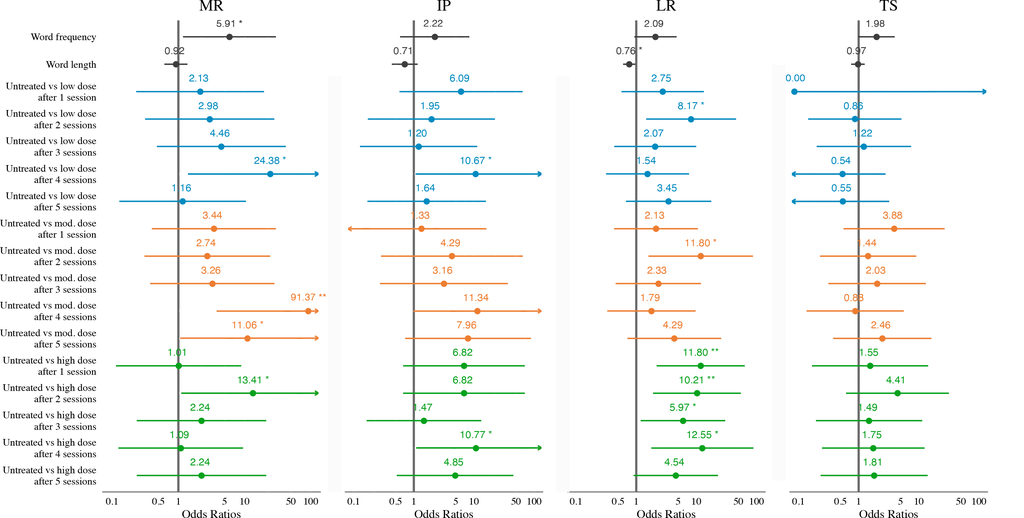

### Supplemental Table I

Table I shows a summary of the outputs of the models used in Analysis 1. The first two coefficients in the table estimate how word frequency and word length moderated the likelihood of a successful naming response over failure for untreated items prior to treatment. Given the stimulus sets were balanced for these lexical properties, these coefficient estimates give a general indication of underlying frequency and length effects on response accuracy. The times_treated coefficients (labelled ‘After 1 treatment session’, etc) estimate stability of naming performance for untreated/control items by comparing naming accuracy of untreated items in the baseline phase against accuracy of the same untreated items as treatment sessions incremented across dose conditions. The dose coefficients estimated baseline accuracy relative to the untreated condition for the low, moderate, and high dose conditions, respectively. The interaction terms provided estimates of the effect of treatment versus no treatment across dose conditions.

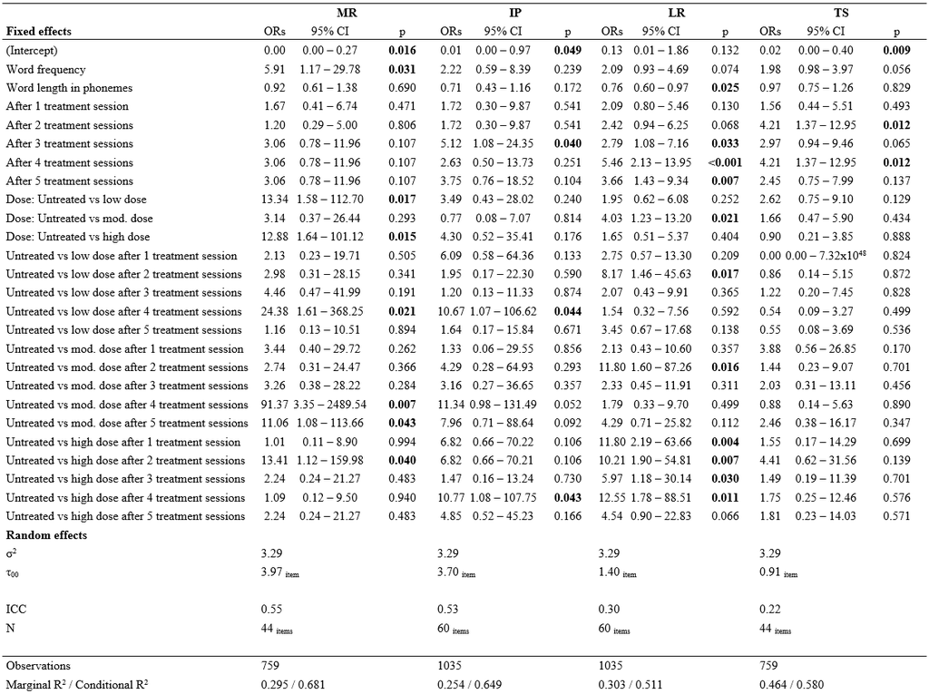

## Analysis 2: Treatment effects, dose effects, and maintenance of these effects

Analysis 2 modelled treatment response, dose effects, and maintenance of these effects using secondary outcome data from the 298-item picture naming test conducted pre-treatment, immediately post-treatment, and at two follow-up time points. A generalised linear mixed effects model was constructed to test for main effects of dose and time and their interactions, with random intercepts by-item. Models with identical fixed-effects structure were fitted to each participant’s data separately allowing within-subject estimation of the effect of treatment versus no treatment for each dose condition and comparison of the effect of each dose condition. The same iterative reduction of model complexity process was used as for Analysis 1.

```r
m2.mr <- glmer(response ~ Freq + Phon_length + time*doseCode + (1 | item_num),
                  family = 'binomial',
                  data = mr.namingTestData,
                  control = glmerControl(optimizer ="bobyqa")) # model converges with these controls
```

```r
m2.ip <- glmer(response ~ Freq + Phon_length + time*doseCode + (1 | item_num),
                  family = 'binomial',
                  data = ip.namingTestData,
                  control = glmerControl(optimizer ="bobyqa")) # model converges with these controls
```

```r
m2.lr <- glmer(response ~ Freq + Phon_length + time*doseCode + (1 | item_num),
                  family = 'binomial',
                  data = lr.namingTestData,
                  control = glmerControl(optimizer ="bobyqa")) # model converges with these controls
```

```r
m2.ts <- glmer(response ~ Freq + Phon_length + time*doseCode + (1 | item_num),
                  family = 'binomial',
                  data = ts.namingTestData,
                  control = glmerControl(optimizer ="bobyqa")) # model converges with these controls
```

### Figure

Forest plots depicting Analysis 2 coefficient estimates (Odds Ratios with 95% confidence intervals) for item-level effects and interaction terms

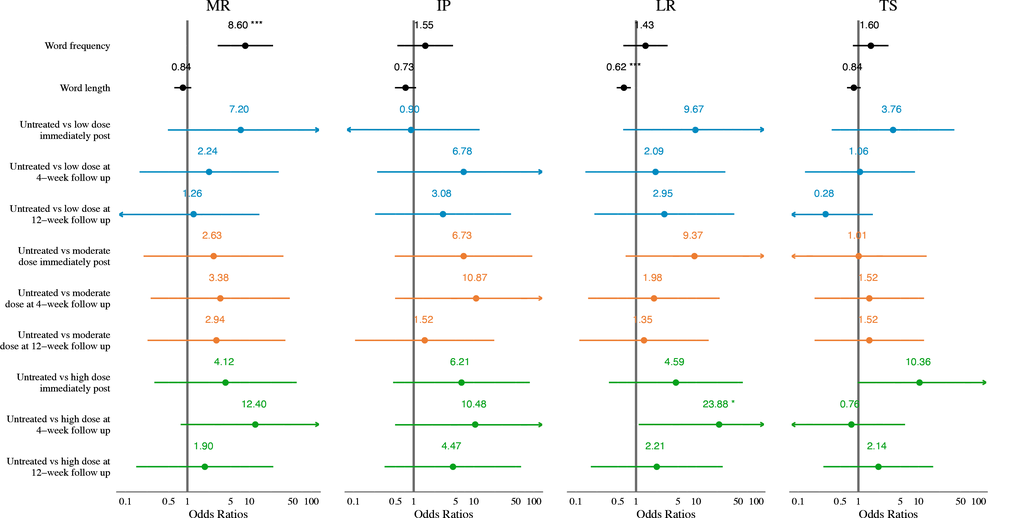

### Supplementary Table II

Table II shows a summary of the outputs of the models used in Analysis 2. The first two coefficients in the table estimated how word frequency and word length moderated the likelihood of a successful naming response over failure for untreated items prior to treatment. The dose coefficients estimated pre-treatment accuracy relative to the untreated condition for the low, moderate, and high dose conditions, respectively. The time coefficients estimated how naming accuracy of untreated items changed over time and so provided an estimate of the effect of naming probe exposure. The interaction terms provided estimates of the effect of treatment versus no treatment across dose conditions and across time.

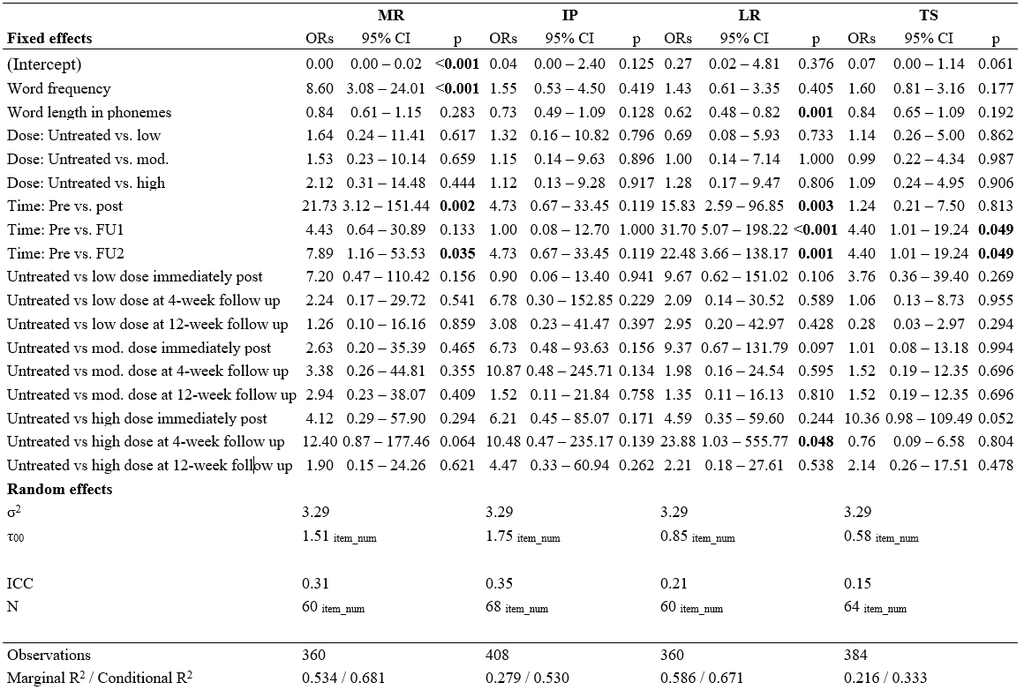

## Summary

Each participant responded differently to treatment. Of the four participants, LR demonstrated greatest learning effects during treatment (Analysis 1) and was the only participant to demonstrate maintenance of treatment versus no-treatment gains four weeks following treatment (Analysis 2). MR and IP demonstrated significant learning effects during treatment but no significant improvement or maintenance following treatment. TS did not demonstrate learning effects. In the accompanying manuscript, we examine factors including dose and schedule, cognitive functions such as self-monitoring ability, and language skills such as underlying lexical semantic and phonological processing that may help understand the observed treatment response variability.

Copyright The Authors 2022 CC-BY-4.0